# P8105_hw3_jn2761

jiaying Ning

10/10/2020

```r
#devtools::install_github("p8105/p8105.datasets", force = TRUE)
```

##problem2

1. Load, tidy, and otherwise wrangle the data. Your final dataset should include all originally observed variables and values; have useful variable names; include a weekday vs weekend variable; and encode data with reasonable variable classes. Describe the resulting dataset (e.g. what variables exist, how many observations, etc).

```r
CHF_df=
   read_csv("./data/accel_data.csv")  %>%
   janitor::clean_names() %>%
    rename(number_of_days = day_id, number_of_week = week)%>%
  mutate(
    weekday.weekend = ifelse(day == "Saturday" | day =="Sunday", "weekend", "weekday")) %>% #create a new column indicate whether it was recorded on weekday or weekend
  relocate(weekday.weekend)#move the variable to front
#Tidy data

CHF_df_tidy =
  pivot_longer(
    CHF_df,  #原数据
    activity_1:activity_1440, #想更改的column
    names_to = "minute",
    names_prefix = "activity_",
    values_to = "activity")
```

In the resulting dataset, I have 50400 observation and 6 variables,the data contain a total of 35 days of observation, week range from first week to fifth week. The dataset contains variables - weekday.weekend: variables that classify whether the observation is made on weekdays of weekend - number_of_days: variables that record the number of days that the observation has been going on - number-of-weeks:variables that record the number of weeks that the observation has been going on - day: variable specify on the specific days in which the observation is recorded - minute: the specific days in which the observation is recorded - activity: the activity counts for each minute of a 24-hour day starting at midnight.

2.Traditional analyses of accelerometer data focus on the total activity over the day. Using your tidied dataset, aggregate accross minutes to create a total activity variable for each day, and create a table showing these totals. Are any trends apparent?

```r
CHF_df_tidy %>%
  group_by(number_of_days) %>%
 summarize(total_activity=sum(activity))
```

```
## # A tibble: 35 x 2
##    number_of_days total_activity
##             <dbl>          <dbl>
##  1              1        480543.
##  2              2         78828.
##  3              3        376254
##  4              4        631105
##  5              5        355924.
##  6              6        307094.
##  7              7        340115.
##  8              8        568839
##  9              9        295431
## 10             10        607175
## # … with 25 more rows
```

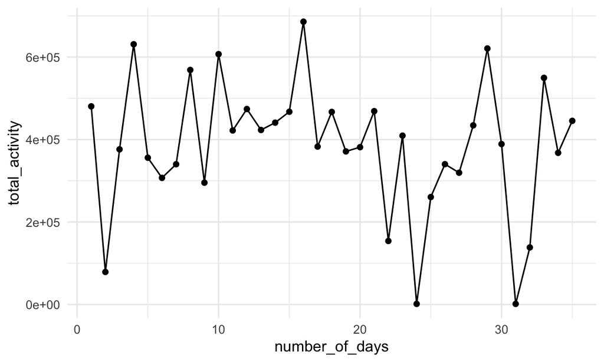

```r
CHF_df_tidy %>%
  group_by(number_of_days) %>%
 summarize(total_activity=sum(activity)) %>%
ggplot(aes(x=number_of_days, y=total_activity)) +
  geom_point() +
  geom_line()
```

3. Accelerometer data allows the inspection activity over the course of the day. Make a single-panel plot that shows the 24-hour activity time courses for each day and use color to indicate day of the week. Describe in words any patterns or conclusions you can make based on this graph.

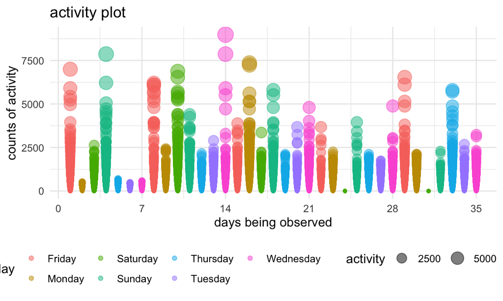

```r
CHF_df_tidy %>%
  group_by(day) %>%
ggplot(aes(x=number_of_days, y = activity,color=day)) +
  geom_point(aes(size = activity),alpha=0.5) +
  labs(
    titles = "activity plot",
    x = "days being observed",
    y = "counts of activity"
  ) +
  scale_x_continuous(
    breaks = c(0,7,14,21,28,35))
```

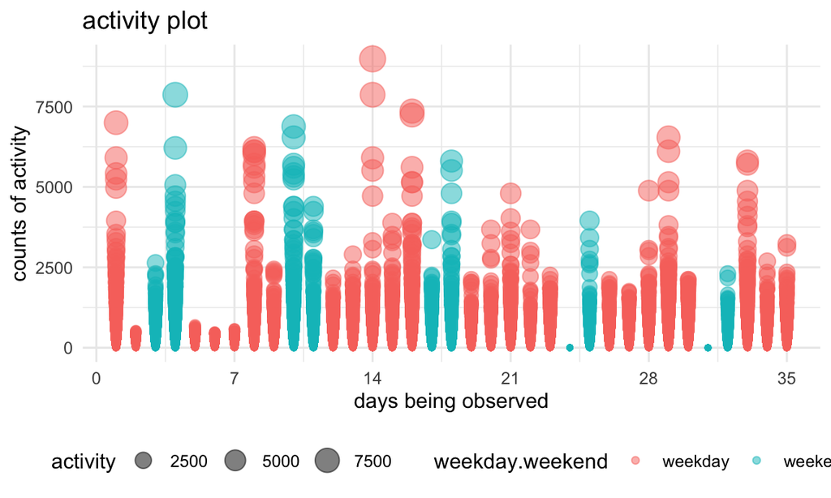

```r
CHF_df_tidy %>%
  group_by(day) %>%
ggplot(aes(x=number_of_days, y = activity,color=weekday.weekend)) +
  geom_point(aes(size = activity),alpha=0.5) +
  labs(
    titles = "activity plot",
    x = "days being observed",
    y = "counts of activity"
  ) +
  scale_x_continuous(
    breaks = c(0,7,14,21,28,35))
```

##problem3

The goal is to do some exploration of this dataset. To that end, write a short description of the dataset, noting the size and structure of the data, describing some key variables, and indicating the extent to which missing data is an issue. Then, do or answer the following (commenting on the results of each):

Do some data cleaning. Create separate variables for year, month, and day. Ensure observations for temperature, precipitation, and snowfall are given in reasonable units. For snowfall, what are the most commonly observed values? Why?

- For some reason I was not able download packages from p8105 github

```r
load("./data/ny_noaa.rda")
```

```r
ny_noaa=
  ny_noaa %>%
   janitor::clean_names() %>%
   separate(date, c("year","month","day"), sep = "([-])") %>%
mutate(
    year = as.numeric(year),
    month = as.numeric(month),
    tmax = as.numeric(tmax),
     tmin = as.numeric(tmin))
```

```r
summary(ny_noaa)
```

```
##       id                 year          month            day
##  Length:2595176     Min.   :1981   Min.   : 1.000   Length:2595176
##  Class :character   1st Qu.:1988   1st Qu.: 4.000   Class :character
##  Mode  :character   Median :1997   Median : 7.000   Mode  :character
##                     Mean   :1996   Mean   : 6.565
##                     3rd Qu.:2005   3rd Qu.:10.000
##                     Max.   :2010   Max.   :12.000
##
##       prcp               snow             snwd             tmax
##  Min.   :    0.00   Min.   :  -13    Min.   :   0.0   Min.   :-389.0
##  1st Qu.:    0.00   1st Qu.:    0    1st Qu.:   0.0   1st Qu.:  50.0
##  Median :    0.00   Median :    0    Median :   0.0   Median : 150.0
##  Mean   :   29.82   Mean   :    5    Mean   :  37.3   Mean   : 139.8
##  3rd Qu.:   23.00   3rd Qu.:    0    3rd Qu.:   0.0   3rd Qu.: 233.0
##  Max.   :22860.00   Max.   :10160    Max.   :9195.0   Max.   : 600.0
##  NA's   :145838     NA's   :381221   NA's   :591786   NA's   :1134358
##       tmin
##  Min.   :-594.0
##  1st Qu.: -39.0
##  Median :  33.0
##  Mean   :  30.3
##  3rd Qu.: 111.0
##  Max.   : 600.0
##  NA's   :1134420
```

```r
ny_noaa %>%
  group_by(snow) %>%
  summarize(n_obs = n()) %>%
arrange(min_rank(desc(n_obs)))
```

```
## # A tibble: 282 x 2
##     snow   n_obs
##    <int>   <int>
##  1     0 2008508
##  2    NA  381221
##  3    25   31022
##  4    13   23095
##  5    51   18274
##  6    76   10173
##  7     8    9962
##  8     5    9748
##  9    38    9197
## 10     3    8790
## # … with 272 more rows
```

The most common value for snow fall is 0 because snowfall only occurs during winter.

Make a two-panel plot showing the average max temperature in January and in July in each station across years. Is there any observable / interpretable structure? Any outliers?

Conclusion: as expected, the average max temperatue is is much higher in July than in January in general. The maximum temperature difference also seems to be less variant during a year and between each year in July than in January. There seems to be couple of outliers both in January and July where some month appear to be extremely cold than usual,

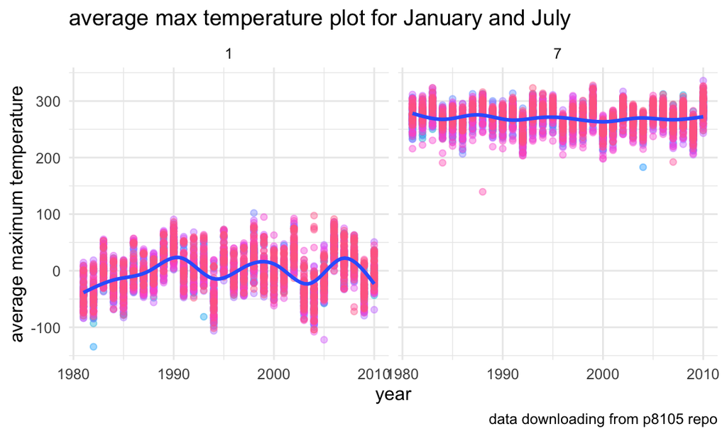

```r
  ny_noaa %>%
  group_by(id,year,month) %>%
  filter(month == 01 | month == 07)%>%
summarise(mean_tmax = mean(tmax,na.rm=TRUE)) %>%
  ggplot(aes(x = year, y = mean_tmax)) +
  geom_point(aes(color = id), show.legend = FALSE, alpha=0.4) +
  geom_smooth(se=FALSE) +
  facet_grid(.~month)  +
  labs(
    titles = "average max temperature plot for January and July",
    x = "year",
    y = "average maximum temperature",
    caption = "data downloading from p8105 repo"
  )
```

Make a two-panel plot showing (i) tmax vs tmin for the full dataset (note that a scatterplot may not be the best option); and (ii) make a plot showing the distribution of snowfall values greater than 0 and less than 100 separately by year.

```r
library(patchwork)


temperature_plot=
ny_noaa %>%
  ggplot(aes(x=tmin,y=tmax)) +
  geom_hex()+
scale_x_continuous(
    breaks = c(-600,-500,-400,-300,-200,-100,0,100,200,300,400,500,600)) +
    labs(titles = "maximum temperature vs minimu temperature ",
       x= "minimum temperature",
       y = "maximum temperature"  )
```

```r
snowfall_plot=
  ny_noaa %>%
  filter(
    0 < snow & snow < 100 ,
          )%>%
  ggplot(aes(x=year,y=snow)) +
  geom_density_2d_filled()  +
scale_x_continuous(
    breaks = c(1980,1985,1990,1995,2000,2005,2010)) +
  labs(titles = "the distribution of snowfall for each year",
        y = "distribution of snowfall"  )
```

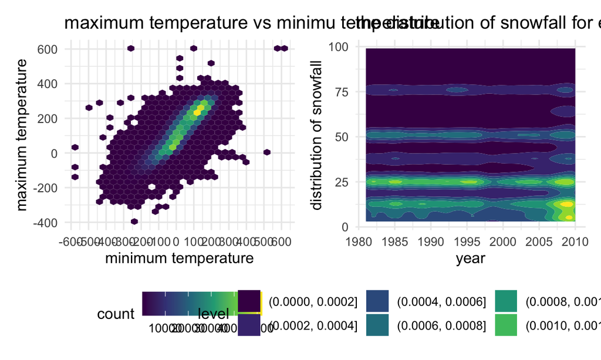

```r
temperature_plot + snowfall_plot
```